# Survey Dataset Project

STAT 202 Final Project

Author

Hayden Sterling, Sasha Boico, Palima Lukins

### Load packages and data

```r
library(tidyverse)
library(moderndive)
library(gapminder)
library(infer)
library(dslabs)
library(skimr)
library(ISLR)

survey <- read_rds(file = "data/survey.rds")
```

## Introduction

The “survey” dataset includes questions about college life, social life, personality, as well as many other categories. Data has been collected on STAT 202 students who took the course from Fall 2021 up until now. The data is not generalizable to any population because there was no randomization in the process of picking who to survey. However, for the sake of many tests that we conduct in this data report, we may assume that it is generalizable to a larger population, which will be specified during some individual parts of this report. In addition, only correlation statements can be made using this data, as this survey did not have random assignment.

## Data Overview

To further investigate the dataset, we will view raw data as well as skim it for any missingness issues that may cause problems in future analysis.

To start, we’ll view the raw data in two ways: by simply examining in the dataset as a whole, and by taking a random sample of 5 observations to take a more detailed look at these observations.

```r
survey
```

```
# A tibble: 1,047 × 64
   quarter   fav_drink   num_party party_bin smoke_cig smoke_weed campus_housing
   <chr>     <fct>           <dbl> <chr>     <chr>     <chr>      <chr>
 1 fall 2023 don't_drink         0 0         No        No         South campus
 2 fall 2023 hard_liquor         7 7+        No        No         North campus
 3 fall 2023 hard_liquor         3 3-4       No        Occasiona… North campus
 4 fall 2023 don't_drink         3 3-4       No        No         South campus
 5 fall 2023 don't_drink         0 0         No        No         South campus
 6 fall 2023 hard_liquor         3 3-4       No        Occasiona… South campus
 7 fall 2023 hard_liquor         3 3-4       Occasion… No         North campus
 8 fall 2023 hard_liquor         1 1-2       No        No         South campus
 9 fall 2023 hard_liquor         2 1-2       Occasion… No         South campus
10 fall 2023 don't_drink         1 1-2       No        No         South campus
# ℹ 1,037 more rows
# ℹ 57 more variables: personality <chr>, followers_insta <dbl>,
#   followers_tiktok <dbl>, salary <dbl>, exercise <dbl>,
#   love_first_sight <chr>, learning_style <fct>, brain_type <fct>,
#   myer_briggs <chr>, fav_sport <chr>, fav_letter <chr>, fav_num <dbl>,
#   hrs_sleep <dbl>, procrastinator <chr>, only_child <chr>, birth_month <chr>,
#   birth_date <chr>, childhood_us <chr>, age_years <dbl>, …
```

```r
survey %>%
  slice_sample(n = 5)
```

```
# A tibble: 5 × 64
  quarter     fav_drink  num_party party_bin smoke_cig smoke_weed campus_housing
  <chr>       <fct>          <dbl> <chr>     <chr>     <chr>      <chr>
1 winter 2023 don't_dri…        15 7+        No        Occasiona… North campus
2 summer 2022 don't_dri…        10 7+        No        No         Neither
3 spring 2022 don't_dri…        NA 5-6       <NA>      <NA>       North campus
4 fall 2021   <NA>              NA <NA>      <NA>      <NA>       <NA>
5 fall 2023   don't_dri…         3 3-4       No        No         South campus
# ℹ 57 more variables: personality <chr>, followers_insta <dbl>,
#   followers_tiktok <dbl>, salary <dbl>, exercise <dbl>,
#   love_first_sight <chr>, learning_style <fct>, brain_type <fct>,
#   myer_briggs <chr>, fav_sport <chr>, fav_letter <chr>, fav_num <dbl>,
#   hrs_sleep <dbl>, procrastinator <chr>, only_child <chr>, birth_month <chr>,
#   birth_date <chr>, childhood_us <chr>, age_years <dbl>, gender_ident <chr>,
#   marry <dbl>, school_year <chr>, height_inches <dbl>, father_height <dbl>, …
```

## Exploratory Data Analysis 1

In our first EDA, we will explore the time that STAT 202 students in the Fall 2021 to Fall 2023 quarters spent exercising, dividing our exploration by gender.

First, we will create a new data set which only contains the exercise and gender varaibles for students taking STAT 202, then look at it by selecting a random sample of n = 10.

```r
EDA_1 <- survey %>%
  select(gender_ident, exercise)

EDA_1 %>%
  slice_sample(n = 10)
```

```
# A tibble: 10 × 2
   gender_ident exercise
   <chr>           <dbl>
 1 Female             NA
 2 Male               NA
 3 Female            120
 4 Female            300
 5 Male              180
 6 Female             NA
 7 Female             NA
 8 Female             NA
 9 Female            120
10 Female             10
```

As can be seen above, there are some missingness issues for the exercise variable.

To determine the exact amount of missing values and gather some further information, we will next take a look at the data using the skim_without_charts() function from skimr.

```r
skim_without_charts(EDA_1)
```

Data summary

| Name | EDA_1 |
| --- | --- |
| Number of rows | 1047 |
| Number of columns | 2 |
| _______________________ |  |
| Column type frequency: |  |
| character | 1 |
| numeric | 1 |
| ________________________ |  |
| Group variables | None |

**Variable type: character**

| skim_variable | n_missing | complete_rate | min | max | empty | n_unique | whitespace |
| --- | --- | --- | --- | --- | --- | --- | --- |
| gender_ident | 0 | 1 | 4 | 6 | 0 | 2 | 0 |

**Variable type: numeric**

| skim_variable | n_missing | complete_rate | mean | sd | p0 | p25 | p50 | p75 | p100 |
| --- | --- | --- | --- | --- | --- | --- | --- | --- | --- |
| exercise | 429 | 0.59 | 693.53 | 7721.95 | 0 | 60 | 180 | 322.5 | 180200 |

As can be further seen in the above skim, the exercise variable has 429 missing observations.

These can be removed using the !is.na() function, which is going to be our next step.

```r
EDA_1 <- EDA_1 %>%
 filter(!is.na(exercise))
```

Now, we can calculate summary statistics for the investigation: the mean, standard deviation, median, interquartile range, minimum, and maximum for exercise. We will store the results in `exercise_summary`.

```r
exercise_summary <- EDA_1 %>%
summarize(mean = mean(exercise),
          std_dev = sd(exercise),
          median = median(exercise),
          IQR = IQR(exercise),
          min = min(exercise),
          max = max(exercise),
          count = n())


exercise_summary
```

```
# A tibble: 1 × 7
   mean std_dev median   IQR   min    max count
  <dbl>   <dbl>  <dbl> <dbl> <dbl>  <dbl> <int>
1  694.   7722.    180  262.     0 180200   618
```

From the above summary statistics, we gather that **the mean time Northwestern students taking STAT 202 spend exercising is 693.53 minutes per week, whereas the median time is 180.00 minutes per week, meaning there might be significant outliers. The IQR is 262.50 minutes and the std_dev is 7721.95 minutes, meaning the data is widely spread. The minimum and maxiumum times spent exercising (0 and 180200 minutes) are quite far from the median and mean. The maximum is certainly an outlier as the time exceeds the number of minutes in a week, therefore the student may have misread the question and input the answer in seconds.**

Lastly, we perform a visualization of the distribution of the weekly exercise time in minutes for Northwestern STAT 202 students by gender, using a side-by-side boxplot. We will remove the positive outliers by limiting the maximum exercise time to a max of 2100 minutes (which means that a students spends 5 hours a day exercising, every day of the week (stated as maximum healthy amount by CDC)) to have a better understanding of the data.

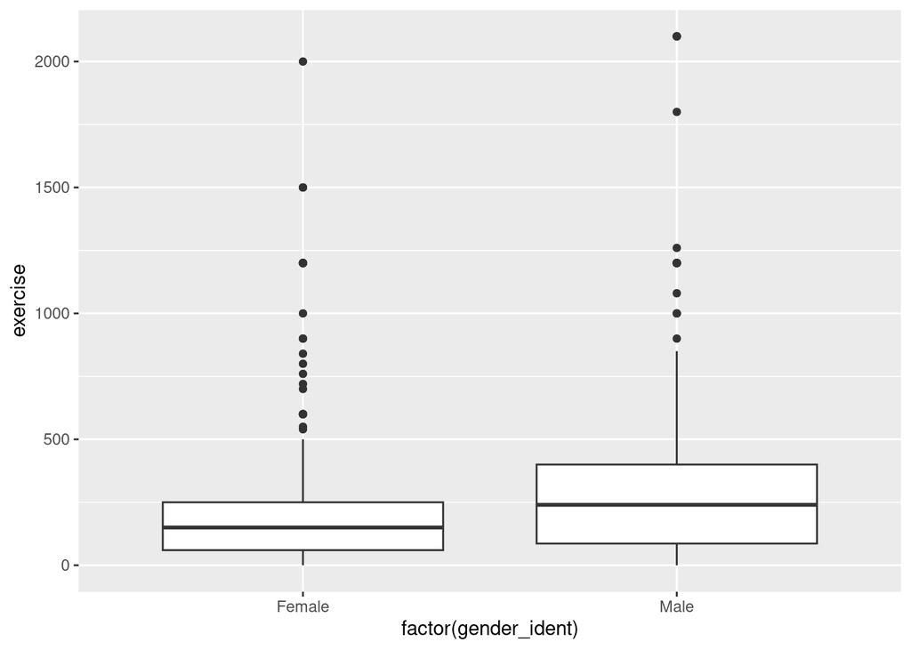

```r
EDA_1 <- EDA_1 %>%
  filter(exercise <= 2100)


ggplot(EDA_1, aes(x = factor(gender_ident), y = exercise)) +
  geom_boxplot()
```

The boxplot shows us we have a significant number of outliers for both genders. We also observe that female-identifying students have a lower median time of exercising than their male-identifying counterparts. Moreover, the IQR for female-identifying students is also much narrower than for male-identifying students. Both distributions are right-skewed.

## Exploratory Data Analysis 2

In exploratory data analysis, we are interested in how a student’s height relates to their father’s height.

First, we will make a new dataset with just the variables we need from the larger survey dataset, then view the raw data with a random sample of n = 10, and finally skim the variables that we are concerned with.

```r
EDA_2 <- survey %>%
  select(height_inches, father_height)

EDA_2 %>%
  slice_sample(n = 10)
```

```
# A tibble: 10 × 2
   height_inches father_height
           <dbl>         <dbl>
 1            62            70
 2            70            72
 3            65            68
 4            NA            NA
 5            64            72
 6            71            75
 7            NA            NA
 8            64            68
 9            64            65
10            64            69
```

```r
EDA_2 %>%
  skim_without_charts()
```

Data summary

| Name | Piped data |
| --- | --- |
| Number of rows | 1047 |
| Number of columns | 2 |
| _______________________ |  |
| Column type frequency: |  |
| numeric | 2 |
| ________________________ |  |
| Group variables | None |

**Variable type: numeric**

| skim_variable | n_missing | complete_rate | mean | sd | p0 | p25 | p50 | p75 | p100 |
| --- | --- | --- | --- | --- | --- | --- | --- | --- | --- |
| height_inches | 190 | 0.82 | 74.12 | 219.70 | 5.2 | 64 | 66 | 70 | 6496.06 |
| father_height | 409 | 0.61 | 80.40 | 270.15 | 6.0 | 68 | 70 | 72 | 6889.76 |

From this, we can see that there are various missingness issues, so we will filter out these missing values.

```r
EDA_2 <- EDA_2 %>%
  filter(!is.na(height_inches) & !is.na(father_height))
```

Next, we are ready to create the visualization, with the x-axis plotting height_inches and the y-axis plotting father_height. Because there was one person who had an extreme value near 6000 inches for their height, which is obviously impossible, we limited the view of the graph just to include the relevent values.

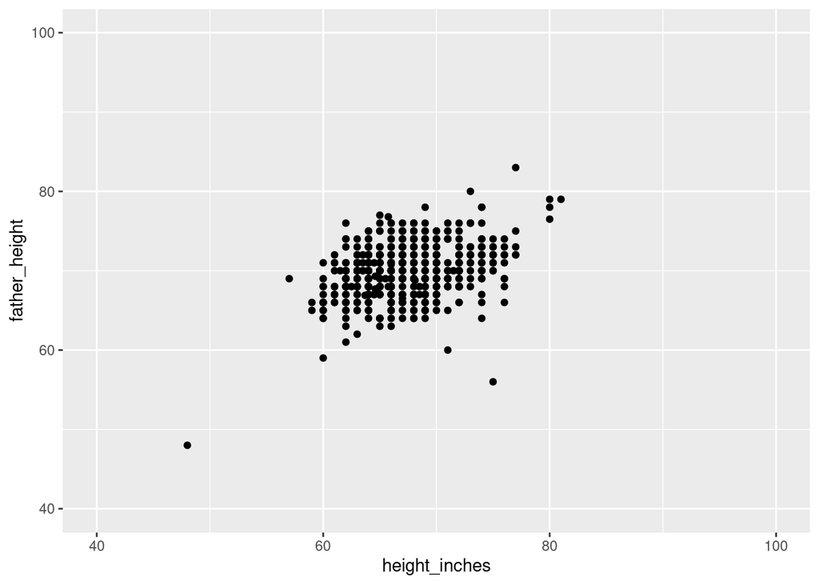

```r
ggplot(data = EDA_2, mapping = aes (x = height_inches, y = father_height))+
  xlim(40,100) +
  ylim(40,100)+
  geom_point()
```

From this scatter plot, we can see that there is a moderate to strong positive linear association. Therefore as the individuals height increases the fathers height also generally increases.

Now we will calculate some summary statistics to further interpret this scatterplot, namely the means for height_inches and father_height, as well as the correlation coefficient between these two variables and the minimum and maximum values of the variable height_inches (to check for extreme outliers).

```r
EDA_2 %>%
  select(father_height, height_inches) %>%
  cor()
```

```
              father_height height_inches
father_height     1.0000000     0.9997383
height_inches     0.9997383     1.0000000
```

```r
EDA_2%>%
  summarize(mean_height_inches = mean(height_inches),
            mean_father_height = mean(father_height),
            min_height_inches = min(height_inches),
            max_height_inches = max(height_inches))
```

```
# A tibble: 1 × 4
  mean_height_inches mean_father_height min_height_inches max_height_inches
               <dbl>              <dbl>             <dbl>             <dbl>
1               77.2               80.6               5.9             6496.
```

From this, we can see that the correlation coefficient is very close to 1 and positive indicating that there is a strong positive association between these two variables. We can also see that the mean height for fathers is slightly larger than the mean height for students, indicating that on average fathers are slightly taller than their children. Additionally, we can see some extreme outliers in the height_inches variable, because the minimum (5.9 inches tall) and maximum (6496 inches tall) are both unreasonable. This confirms that various extreme and impossible values may be affecting the results of our graph.

## Regression Analysis

For our regression model, we would like to use the numeric variable, followers_insta, and the categorical variable, personality, to predict the numerical variable num_party.

```r
regression_data <- survey %>%
  select(followers_insta, personality, num_party) %>%
  filter(!is.na(followers_insta) | !is.na(personality) | !is.na(num_party))
```

Now, we will make an interaction model, and get a summary of the coefficients. This interaction model will create two lines, one predicting the number of parties attended by extroverts, and the other predicting the number of parties attended by introverts.

```r
regression_interaction <- lm(num_party ~ followers_insta + personality + followers_insta * personality, data = regression_data)
summary(regression_interaction)$coefficients
```

```
                                          Estimate   Std. Error     t value
(Intercept)                           2.2357126178 0.7877319972  2.83816403
followers_insta                       0.0022613065 0.0005215068  4.33610175
personalityIntrovert                 -0.5941755890 0.9318274385 -0.63764552
followers_insta:personalityIntrovert  0.0000213555 0.0006486576  0.03292261
                                        Pr(>|t|)
(Intercept)                          0.004680299
followers_insta                      0.000016829
personalityIntrovert                 0.523931096
followers_insta:personalityIntrovert 0.973746506
```

From this interaction model, we can tell that Extrovert is the baseline group because the model gives us the offsets values for introverts: the offset in intercept for introverts, personalityIntrovert, and the offset in slope for introverts, followers_insta:personalityIntrovert. Looking at the Estimate column, we can see that the offset in slope for introverts is exceedingly small. This means that the slopes of the two lines would be very similar. Because of this, we can instead create a parallel slopes model which forces both slopes to be the same, thus simplifying the model.

```r
regression_parallel <- lm(num_party ~ followers_insta + personality, data = regression_data)
summary(regression_parallel)$coefficients
```

```
                        Estimate   Std. Error   t value     Pr(>|t|)
(Intercept)           2.21729755 0.5542375328  4.000627 7.049782e-05
followers_insta       0.00227511 0.0003098782  7.341951 6.368014e-13
personalityIntrovert -0.56888417 0.5269986869 -1.079479 2.807776e-01
```

In this model, there are three coefficients. Once again, we will only pay attention to the values in the Estimate column, as these are the estimated values for each coefficient. We will start with this equation format:

$$\widehat{numparty} = b_0 + b_1\left(followers\_insta \right) + b_2\left(1_{personality}\right)$$

Now, we can use these values and the equation formate to create our parallel slopes equation for the fitted lines.

$$\widehat{numparty} = 2.21729755 + 0.00227511\left(followers\_insta \right) + -0.56888417\left(1_{personality}\right)$$

Now, we can visualise the lines using a ggplot scatterplot and create our two lines using geom_parallel_slopes().

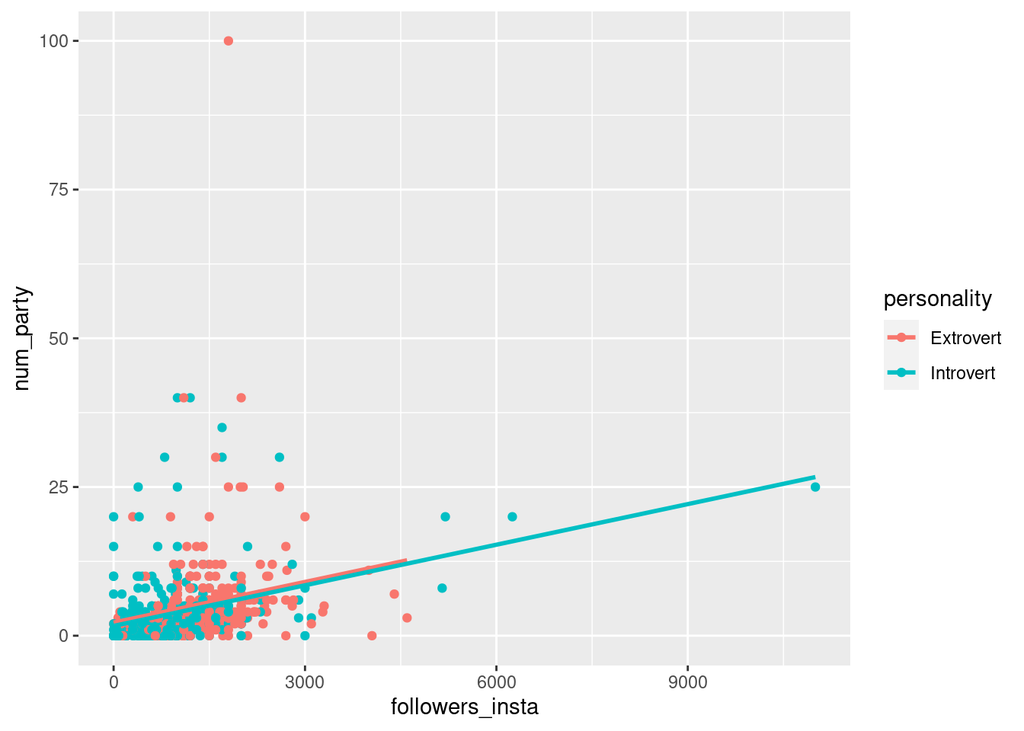

```r
ggplot(regression_data, aes(x = followers_insta, y = num_party, color = personality)) +
  geom_point() +
  geom_parallel_slopes(se = FALSE)
```

As we can see, the lines have the same slope. The extrovert line is slightly above the introvert line because the personalityIntrovert value is -0.56888417, meaning the introvert line intercept is smaller than the extrovert line intercept. This model would be used to predict the number of parties people attend based on their instagram followers and personality type.

## Confidence Interval

```r
CI_tidy <- survey %>%
  filter(!is.na(campus_housing) & !is.na(personality))


CI_tidy %>%
  count(campus_housing, personality)
```

```
# A tibble: 6 × 3
  campus_housing personality     n
  <chr>          <chr>       <int>
1 Neither        Extrovert      39
2 Neither        Introvert      55
3 North campus   Extrovert     191
4 North campus   Introvert     159
5 South campus   Extrovert     139
6 South campus   Introvert     214
```

```r
prop.test(x = c(191, 139), n = c((191+159),(139+214)), conf.level = 0.95, correct=FALSE)
```

```
    2-sample test for equality of proportions without continuity correction

data:  c(191, 139) out of c((191 + 159), (139 + 214))
X-squared = 16.291, df = 1, p-value = 5.431e-05
alternative hypothesis: two.sided
95 percent confidence interval:
 0.07901694 0.22487622
sample estimates:
   prop 1    prop 2
0.5457143 0.3937677
```

Therefore, **we are 95% confident that the difference in proportion of extrovert students living in North Campus and extrovert students living in South Campus is between 0.07901 and 0.2249.**

## Hypothesis Test

The Scientific Research Publishing Journal (https://www.scirp.org/journal/paperinformation.aspx?paperid=40111#:~:text=As%20educators%2C%20we%20often%20ask,percent%20of%20the%20student%20body.) claims that approximately 40% of college students identify as introverted. For our hypothesis test, we would like to see if our data from the survey dataset does or does not agree with this claim. If it does not, we will determine whether our data indicates a proportion of more than 0.4 or less than 0.4. Although, as previously stated, our dataset is not generalizable to any population, we will act as though it is generalizable to the entire population of college students for the sake of this hypothesis test.

To start, we will formulate our null and alternative hypothesis. Because we are dealing with a proportion, we will use the variable π in our hypotheses.

$$H_0:\pi_{introvert} = 0.4$$
$$H_A:\pi_{introvert} \ne 0.4$$
Next, we will determine a significance level, $\alpha$, which will be the maximum accepted value of our p-value. This significance level is the chance under the null hypothesis that our sample would produce a result this extreme, thus if our p-value is less than this $\alpha$ value, then we will reject the null hypothesis. If not, we will fail to reject it. For this experiment, we will use an $\alpha$ value of 0.05. Before computing the p-value, we first must find the number of people who identify as an introvert vs extrovert in our dataset using data wrangling.

```r
survey %>%
  group_by(personality) %>%
  summarize(n = n())
```

```
# A tibble: 3 × 2
  personality     n
  <chr>       <int>
1 Extrovert     369
2 Introvert     428
3 <NA>          250
```

As we can see, there are 369 people who identify as an extrovert and 428 who identify as an introvert, as well as 250 N/A values (meaning that we could not collect data about the personality types of 250 of the peopel who took this survey). We will not count these N/A values in our proportion because we do not know their personality types. Now, we will use a prop.test to compute our p-value because we are concerned with a proportion.

```r
prop.test(x = 428, n = (369 + 428), p = 0.4, correct = FALSE)
```

```
    1-sample proportions test without continuity correction

data:  428 out of (369 + 428), null probability 0.4
X-squared = 62.341, df = 1, p-value = 2.888e-15
alternative hypothesis: true p is not equal to 0.4
95 percent confidence interval:
 0.5023014 0.5713711
sample estimates:
        p
0.5370138
```

According to this hypothesis test, assuming that the proportion of college kids who identify as an introvert is 0.4, the probability of observing data as extreme as ours is 2.888e-15. Because this p-value is much smaller than our threshold alpha value of 0.05, we reject the null hypothesis and can assume that the alternative hypothesis is true. This means that the true proportion of college kids who identify as an introvert is not actually 0.4. According to the sample estimate of this prop.test, a more accurate proportion would be 0.537.

Once again, because we cannot generalize this dataset to any population, these findings are likely not actually true, and we cannot assume that the true proportion of college kids identifying as an introvert in 0.537. However, for the sake of this hypothesis test, we assumed that the dataset was generalizable.

## Conclusions

This dataset is a very flawed one. There are plenty of NA values across many variables. We are not able to generalize the dataset to any larger population. Despite these flaws, we have conducted a lot of research on this dataset and explored it thouroughly.

In our exploratory data analyses, we further explored a variety of variables. We plotted the distribution of number of minutes of exercise for both genders with boxplots and found that males have both a high average number of minutes exersiced and a wider spread than females do. We also determined that the relationship between the height of students and the height of their fathers was a strong positive linear association by making a scatterplot.

In our regression analysis, we used a parallel slopes model to predict the number of parties people attended using their number of instagram followers and their personality type. This was done by creating two fitted lines, one for introverts and one for extroverts.

We created a 95% confidence interval to determine if there was a difference in the proportion of extroverts living in North Campus and extroverts living in South Campus. According to this data set, there is likely a difference.

Finally, we conducted a hypothesis test to evalutate the validity of a claim made by the Scientific Research Publishing Journal, that approximately 40% of college students identify as introverts. We were sufficiently able to disprove this null hypothesis and claim that the alternative hypothesis, this proportion is not equal to 0.4, is instead true. Our prop.test told us a more likely estimate of this proportion is around 0.537, or 53.7%.

Once again, because this dataset is so flawed and is not generalizable to any larger population, the claim we made in the hypothesis test may likely not be true. If we wanted to make solid, widely applicable claims, we would have to conduct research on a different more generalizable dataset.

Overall, in making this project we thouroughly researched the survey dataset and learned a lot about the tendencies and traits of Northwestern STAT 202 students.